# CueStrength controls (within subject)

Manuel Bohn

23 3 2018

```r
###
library(tidyverse)
library(knitr)
library(langcog)
library(ggthemes)
## importing data
d <- bind_rows(read_csv(file="cue_control_1.data.csv"),
               read_csv(file="cue_control_2.data.csv")) %>%
  mutate(trial_type = ifelse(trial == "train", "train", "test"))
```

In all of the following experiments, I only ran the “look + label” condition. This was the one we ran in the first place (for MCC) and all the previous studies suggested that it does not make a difference what the utterance is composed of.

Both experiments are within-subject with 40 participants each, with three trials per condition, which gives us the same 120 data points per condition as usual.

Conditions:

- Barrier (bar): One object is blocked by the barrier.
- Later (abs): One object is absent when the utterance starts and appears later. It appears after the agent has said “Oh cool” but before the label is uttered for the first time.
- Test (no): Usual informativeness condition.

The only difference between the two experiments is that I removed the “Can you give her the toy she wants” sentence, displayed during the choice phase, in the first experiment and put it back for the replication. I did this because the effect was so strong in the previous studies and I was looking for ways to make it more variable. For the replication, I simply put it back because the effect in the test condition was rather small. It’s kind of surprising that it seems to make a difference. I guess what it does is that it reminds participants to pay attention to the agents and thereby prevents them from “zoning out” and adopting a simple response strategy.

Links to experiments in case you want to have a look:

Control: https://langcog.stanford.edu/expts/cue/exp/within_s/cue_control1.html

Replication: https://langcog.stanford.edu/expts/cue/exp/within_s/cue_control2.html

I moved all the sanity, trial and agent checks to the bottom. They look fine overall.

Here is the overall plot, conditions by experiment.

The controls seem to work, even though the overall effect in the test condition is substantially reduced compared to previous studies. The controls seem to “infect” the test, probably because some people adopt the strategy to simply ignore the second table. We know from the between experiments that the test effect is much stronger when presented alone. To complete things, we could run the controls between subject as well.

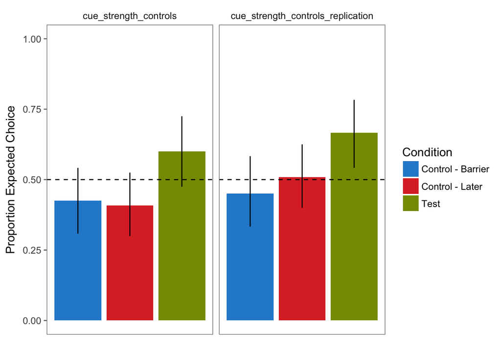

```r
ms <- d %>%
  filter(trial_type == "test") %>%
  group_by(control,experiment, id) %>%
  summarise(correct = mean(correct)) %>%
  multi_boot_standard(col = "correct")

ggplot(ms,
       aes(x = control, y = mean, fill = control)) +
  geom_bar(stat="identity") +
  geom_linerange(aes(ymin = ci_lower, ymax = ci_upper)) +
  facet_wrap(~ experiment) +
  geom_hline(yintercept = 0.5, lty=2)+
  labs(x="",y="Proportion Expected Choice")+
  theme_few(base_size = 12) +
  ylim(0,1)+
  theme(axis.text.x=element_blank(),axis.ticks.x=element_blank())+
  scale_fill_solarized(name="Condition",
                     breaks=c("abs", "bar","no"),
                     labels=c("Control - Barrier", "Control - Later","Test"))
```

Tests against chance per condition. We only have 3 trials per subject per condition, that’s why t-tests aren’t the best option. I used wilcoxon tests instead. There is no Bayesian version of a wilcoxon test, yet.

```r
## Wilcoxon tests against chance
library(exactRankTests)
d %>%
  filter(trial_type == "test") %>%
  group_by(experiment,control, id) %>%
  summarise(correct = mean(correct)) %>%
  summarise(correct = list(correct)) %>%
  group_by(experiment,control) %>%
  mutate(mean= mean(unlist(correct)),
         stat = wilcox.exact(unlist(correct), mu = 0.5)$statistic,
         p = wilcox.exact(unlist(correct), mu = 0.5)$p.value) %>%
  select(experiment,control,mean,stat,p) %>%
  knitr::kable(digits = 3)
```

| experiment | control | mean | stat | p |
| --- | --- | --- | --- | --- |
| cue_strength_controls | abs | 0.425 | 268.5 | 0.054 |
| cue_strength_controls | bar | 0.408 | 261.5 | 0.040 |
| cue_strength_controls | no | 0.600 | 496.0 | 0.227 |
| cue_strength_controls_replication | abs | 0.450 | 330.5 | 0.267 |
| cue_strength_controls_replication | bar | 0.508 | 370.0 | 0.588 |
| cue_strength_controls_replication | no | 0.667 | 571.5 | 0.023 |

Brm Models for the two experiments. Reference level is the test condition.

Results are the same in both experiments. The estimates for both control conditions are negative and the CIs do not overlap with zero. Bottom line: More correct choice in the test compared to the two control conditions.

In the second model, the CI for the intercept does not overlap with 0, reflecting the result of the Wilcoxon test.

If we want to run kids in this, the barrier control might be more difficult because it has and additional perspective taking component. Therefore, if we were to only run one of them, we should probably do the “later” condition.

```r
## model
library(brms)
# controls

data_inf <- d %>%
  filter(trial_type == "test" & experiment == "cue_strength_controls") %>%
  mutate(control  = as.factor(control))

data_inf$control =  relevel(data_inf$control,"no")

# registered  model
bm <- brm(correct ~ control +
              (control |id) + (control |agent),
          data = data_inf, family = bernoulli(),
          control = list(adapt_delta = 0.90),
          iter = 5000)
```

[output not shown]

[output cut: 40 more lines]

[output not shown]

```r
summary(bm)
```

```
##  Family: bernoulli
##   Links: mu = logit
## Formula: correct ~ control + (control | id) + (control | agent)
##    Data: data_inf (Number of observations: 360)
## Samples: 4 chains, each with iter = 5000; warmup = 2500; thin = 1;
##          total post-warmup samples = 10000
##     ICs: LOO = NA; WAIC = NA; R2 = NA
##
## Group-Level Effects:
## ~agent (Number of levels: 11)
##                            Estimate Est.Error l-95% CI u-95% CI Eff.Sample
## sd(Intercept)                  0.42      0.33     0.01     1.22       3535
## sd(controlabs)                 0.64      0.50     0.03     1.83       3264
## sd(controlbar)                 0.89      0.62     0.05     2.33       2528
## cor(Intercept,controlabs)     -0.13      0.50    -0.92     0.84       4514
## cor(Intercept,controlbar)     -0.16      0.49    -0.91     0.82       4407
## cor(controlabs,controlbar)    -0.03      0.49    -0.88     0.85       4863
##                            Rhat
## sd(Intercept)              1.00
## sd(controlabs)             1.00
## sd(controlbar)             1.00
## cor(Intercept,controlabs)  1.00
## cor(Intercept,controlbar)  1.00
## cor(controlabs,controlbar) 1.00
##
## ~id (Number of levels: 40)
##                            Estimate Est.Error l-95% CI u-95% CI Eff.Sample
## sd(Intercept)                  3.08      0.77     1.87     4.87       2261
## sd(controlabs)                 1.40      0.80     0.12     3.18       2013
## sd(controlbar)                 2.01      0.87     0.45     3.97       1653
## cor(Intercept,controlabs)     -0.50      0.39    -0.97     0.48       4319
## cor(Intercept,controlbar)     -0.23      0.39    -0.86     0.58       4950
## cor(controlabs,controlbar)    -0.02      0.46    -0.87     0.80       1679
##                            Rhat
## sd(Intercept)              1.00
## sd(controlabs)             1.00
## sd(controlbar)             1.00
## cor(Intercept,controlabs)  1.00
## cor(Intercept,controlbar)  1.00
## cor(controlabs,controlbar) 1.00
##
## Population-Level Effects:
##            Estimate Est.Error l-95% CI u-95% CI Eff.Sample Rhat
## Intercept      0.81      0.62    -0.37     2.10       1997 1.00
## controlabs    -1.47      0.57    -2.66    -0.41       4374 1.00
## controlbar    -1.73      0.69    -3.25    -0.47       3893 1.00
##
## Samples were drawn using sampling(NUTS). For each parameter, Eff.Sample
## is a crude measure of effective sample size, and Rhat is the potential
## scale reduction factor on split chains (at convergence, Rhat = 1).
```

```r
# replication
data_inf <- d %>%
  filter(trial_type == "test" & experiment == "cue_strength_controls_replication") %>%
  mutate(control  = as.factor(control))

data_inf$control =  relevel(data_inf$control,"no")

# registered  model
bm_rep <- brm(correct ~ control +
              (control |id) + (control |agent),
          data = data_inf, family = bernoulli(),
          control = list(adapt_delta = 0.90),
          iter = 5000)
```

[output not shown]

[output cut: 40 more lines]

[output not shown]

```r
summary(bm_rep)
```

```
##  Family: bernoulli
##   Links: mu = logit
## Formula: correct ~ control + (control | id) + (control | agent)
##    Data: data_inf (Number of observations: 360)
## Samples: 4 chains, each with iter = 5000; warmup = 2500; thin = 1;
##          total post-warmup samples = 10000
##     ICs: LOO = NA; WAIC = NA; R2 = NA
##
## Group-Level Effects:
## ~agent (Number of levels: 11)
##                            Estimate Est.Error l-95% CI u-95% CI Eff.Sample
## sd(Intercept)                  0.77      0.51     0.05     2.00       3144
## sd(controlabs)                 1.83      1.29     0.13     4.88       1964
## sd(controlbar)                 0.77      0.60     0.03     2.25       3345
## cor(Intercept,controlabs)     -0.12      0.47    -0.88     0.80       5572
## cor(Intercept,controlbar)     -0.06      0.49    -0.89     0.86      10000
## cor(controlabs,controlbar)     0.30      0.47    -0.74     0.94       6406
##                            Rhat
## sd(Intercept)              1.00
## sd(controlabs)             1.00
## sd(controlbar)             1.00
## cor(Intercept,controlabs)  1.00
## cor(Intercept,controlbar)  1.00
## cor(controlabs,controlbar) 1.00
##
## ~id (Number of levels: 40)
##                            Estimate Est.Error l-95% CI u-95% CI Eff.Sample
## sd(Intercept)                  3.31      0.92     1.90     5.45       2840
## sd(controlabs)                 3.53      1.86     1.08     7.93       1683
## sd(controlbar)                 1.96      0.93     0.33     3.96       1848
## cor(Intercept,controlabs)      0.09      0.35    -0.64     0.70       6656
## cor(Intercept,controlbar)     -0.42      0.37    -0.93     0.47       7536
## cor(controlabs,controlbar)    -0.12      0.38    -0.84     0.59       3963
##                            Rhat
## sd(Intercept)              1.00
## sd(controlabs)             1.00
## sd(controlbar)             1.00
## cor(Intercept,controlabs)  1.00
## cor(Intercept,controlbar)  1.00
## cor(controlabs,controlbar) 1.00
##
## Population-Level Effects:
##            Estimate Est.Error l-95% CI u-95% CI Eff.Sample Rhat
## Intercept      1.60      0.76     0.26     3.26       3980 1.00
## controlabs    -2.27      1.18    -4.94    -0.22       2764 1.00
## controlbar    -1.55      0.71    -3.14    -0.30       5215 1.00
##
## Samples were drawn using sampling(NUTS). For each parameter, Eff.Sample
## is a crude measure of effective sample size, and Rhat is the potential
## scale reduction factor on split chains (at convergence, Rhat = 1).
```

Sanity checks.

```r
## performance in training and test
d %>%
  group_by(trial_type,experiment) %>%
  summarise(n = length(unique(id)),
            correct = mean(correct)) %>%
  knitr::kable(digits = 3)
```

| trial_type | experiment | n | correct |
| --- | --- | --- | --- |
| test | cue_strength_controls | 40 | 0.478 |
| test | cue_strength_controls_replication | 40 | 0.542 |
| train | cue_strength_controls | 40 | 0.962 |
| train | cue_strength_controls_replication | 40 | 0.938 |

First, check how much data for trial 1 we have per condition (order was completely randomized). Quite some variation.

```r
d %>%
  filter(trial == "1") %>%
  group_by(control,experiment) %>%
  summarise(n = length(unique(id)),
            correct = mean(correct)) %>%
  knitr::kable(digits = 2)
```

| control | experiment | n | correct |
| --- | --- | --- | --- |
| abs | cue_strength_controls | 13 | 0.38 |
| abs | cue_strength_controls_replication | 11 | 0.36 |
| bar | cue_strength_controls | 15 | 0.60 |
| bar | cue_strength_controls_replication | 19 | 0.68 |
| no | cue_strength_controls | 12 | 0.67 |
| no | cue_strength_controls_replication | 10 | 0.90 |

Plot for trial 1. Very variable but same qualitative pattern. Test seems much weaker in the first experiment, which reflects the overall result

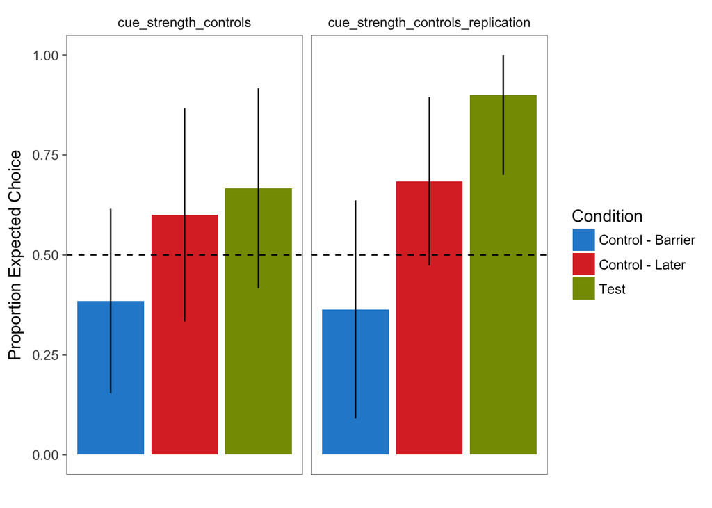

```r
ms <- d %>%
  filter(trial == "1") %>%
  group_by(control,experiment, id) %>%
  summarise(correct = mean(correct)) %>%
  multi_boot_standard(col = "correct")

ggplot(ms,
       aes(x = control, y = mean, fill = control)) +
  geom_bar(stat="identity") +
  geom_linerange(aes(ymin = ci_lower, ymax = ci_upper)) +
  geom_hline(yintercept = 0.5, lty=2)+
  facet_wrap(~ experiment) +
  labs(x="",y="Proportion Expected Choice")+
  theme_few(base_size = 12) +
  ylim(0,1)+
  theme(axis.text.x=element_blank(),axis.ticks.x=element_blank())+
  scale_fill_solarized(name="Condition",
                     breaks=c("abs", "bar","no"),
                     labels=c("Control - Barrier", "Control - Later","Test"))
```

Effect of target object location on table. Inner = closer to the agent, outer = further away. Interestingly the bias to pick the inner object was not there in the replication.

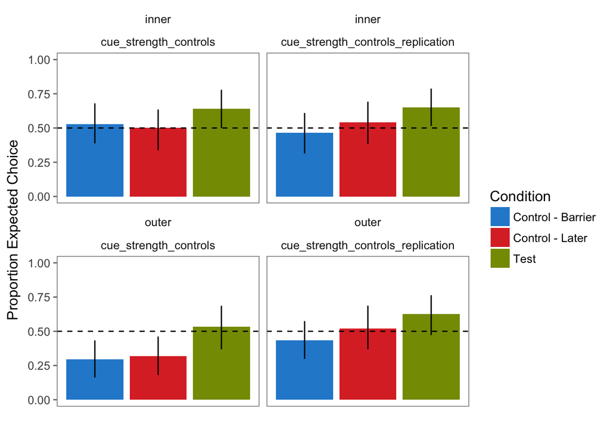

```r
## performance in training and test
ms <- d %>%
  filter(trial_type == "test") %>%
  group_by(targetOnTable,control,experiment, id) %>%
  summarise(correct = mean(correct)) %>%
  multi_boot_standard(col = "correct")

ggplot(ms,
       aes(x = control, y = mean, fill = control,frame = targetOnTable)) +
  geom_bar(stat="identity") +
  geom_linerange(aes(ymin = ci_lower, ymax = ci_upper)) +
  geom_hline(yintercept = 0.5, lty=2)+
  facet_wrap(targetOnTable~ experiment) +
  labs(x="",y="Proportion Expected Choice")+
  theme_few(base_size = 12) +
  ylim(0,1)+
  theme(axis.text.x=element_blank(),axis.ticks.x=element_blank())+
  scale_fill_solarized(name="Condition",
                     breaks=c("abs", "bar","no"),
                     labels=c("Control - Barrier", "Control - Later","Test"))
```

Condition by trial overall. Looks pretty random.

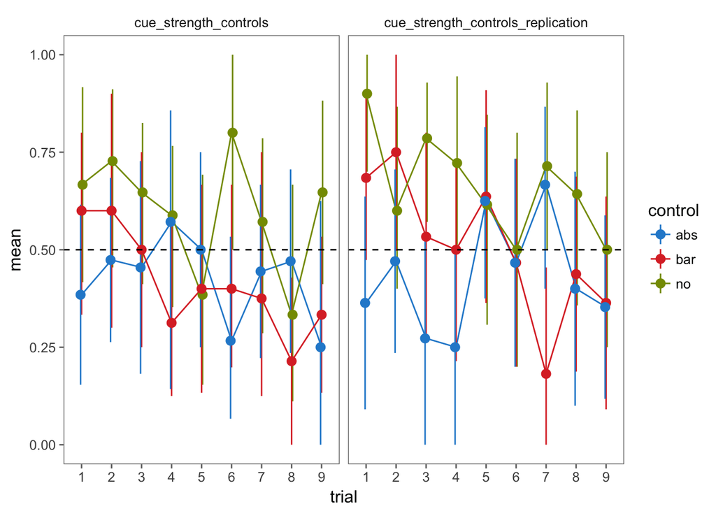

```r
ms <- d %>%
  filter(trial_type == "test") %>%
  group_by(control,experiment, trial, id) %>%
  summarise(correct = mean(correct)) %>%
  multi_boot_standard(col = "correct")

ggplot(ms,
       aes(x = trial, y = mean, col = control)) +
  geom_line(aes(group= control)) +
  facet_wrap(~ experiment) +
  geom_pointrange(aes(ymin = ci_lower, ymax = ci_upper),
                  position = position_dodge(width = .1)) +
  geom_hline(yintercept = 0.5, lty=2)+
  theme_few() +
  scale_colour_solarized()
```

Conditions by agents.

```r
# d %>%
#   filter(trial_type == "test") %>%
#   group_by(agent,condition) %>%
#   summarise(n = length(agent),
#             correct = mean(correct)) %>%
#   knitr::kable(digits = 2)
```

Agent effect. For whatever reason, they seem to think that Elephant, Frog and Monkey are particularly informative.

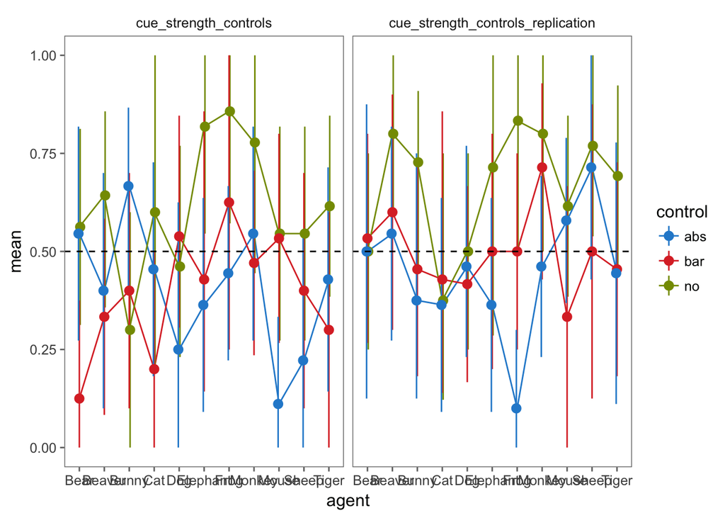

```r
ms <- d %>%
  filter(trial_type == "test") %>%
  group_by(control,experiment, agent, id) %>%
  summarise(correct = mean(correct)) %>%
  multi_boot_standard(col = "correct")

ggplot(ms,
       aes(x = agent, y = mean, col = control)) +
  geom_line(aes(group= control)) +
  geom_pointrange(aes(ymin = ci_lower, ymax = ci_upper),
                  position = position_dodge(width = .1)) +
  geom_hline(yintercept = 0.5, lty=2)+
  facet_wrap(~ experiment) +
  theme_few() +
  scale_colour_solarized()
```